# Turtles tidied data

Eric Coyle

2/21/2021

```r
library(here)
library(tidyverse)
library(naniar)
library(janitor)
library(shiny)
library(paletteer)
library(ggmap)
library(rgeos)
library(rgdal)
library(devtools)
turtles<-read.csv(here("Final Project","Official Final Project Documents/Turtle_data.csv"))
```

```r
turtles_tidy<-turtles%>%
  na_if("")%>%
  na_if("0")%>%
  na_if("0.0")%>%
  mutate(dead_alive_new=if_else(Dead_Alive=="alive","Alive",Dead_Alive))
```

```r
library(lubridate)
turtles3<-turtles_tidy%>%
  mutate(DateCapture_new=dmy(DateCapture))%>%
  filter(!is.na(DateCapture_new))%>%
  mutate(Capture_month=month(DateCapture_new))%>%
  mutate(Capture_day=day(DateCapture_new))%>%
  mutate(capture_week_day=wday(DateCapture_new))
turtles3<-clean_names(turtles3)
head(turtles3)
```

```
##   year turtle_id research_type date_capture      species master_tag dead_alive
## 1 1995         1 Misc. Tagging    16-May-95        Green     QQS241      Alive
## 2 1995         1 Misc. Tagging    16-May-95        Green     QQS241      Alive
## 3 1995         2 Misc. Tagging    24-Apr-95   Loggerhead     QQV299      Alive
## 4 1995         2 Misc. Tagging    24-Apr-95   Loggerhead     QQV299      Alive
## 5 1995         3 Misc. Tagging    12-Jun-95 Kemps_Ridley     QQV296      Alive
## 6 1995         3 Misc. Tagging    12-Jun-95 Kemps_Ridley     QQV296      Alive
##   record_type inconel_tag  body_area    pit_tag body_area_pit date_release
## 1     Release      QQS241  Left Rear       None          <NA>    17-May-95
## 2     Release      QQS242 Right Rear       None          <NA>    17-May-95
## 3     Release      QQV299  Left Rear NOT TAGGED          <NA>    26-May-95
## 4     Release      QQV300 Right Rear NOT TAGGED          <NA>    26-May-95
## 5     Release      QQV296  Left Rear       None          <NA>    12-Jun-95
## 6     Release      QQV297 Right Rear       None          <NA>    12-Jun-95
##        gear scl_notch scl_tip  scw ccl_notch ccl_tip  ccw circumference girth
```

[output cut: 69 more lines]

```r
view(turtles3)
```

#mapping for release and capture sites

```r
turtles3%>%
  select(cap_latitude,cap_longitude)%>%
  summary()
```

```
##   cap_latitude   cap_longitude
##  Min.   :33.49   Min.   :-79.08
##  1st Qu.:34.84   1st Qu.:-76.38
##  Median :34.93   Median :-76.27
##  Mean   :34.96   Mean   :-76.24
##  3rd Qu.:35.05   3rd Qu.:-76.13
##  Max.   :38.41   Max.   :-75.47
```

```r
cap_lat <- c(33.49, 38.41)
cap_long <- c(-79.08, -75.47)
bbox <- make_bbox(cap_long, cap_lat, f = 0.1)
```

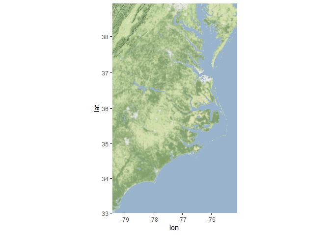

```r
cap_map_base <- get_map(bbox, maptype = "terrain-background", source = "stamen")
ggmap(cap_map_base)
```

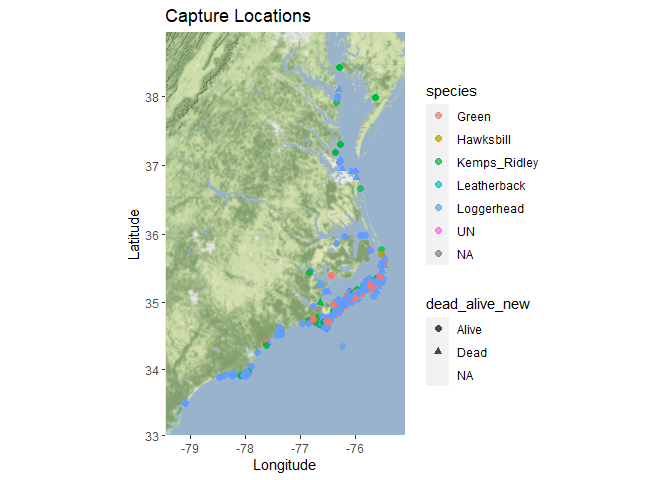

```r
ggmap(cap_map_base) +
  geom_point(data = turtles3, aes(cap_longitude,cap_latitude,color=species,shape=dead_alive_new), size = 2, alpha = 0.7) +
           labs(x = "Longitude", y = "Latitude", title = "Capture Locations")
```

```r
turtles3%>%
  select(rel_latitude,rel_longitude)%>%
  summary()
```

```
##   rel_latitude   rel_longitude
##  Min.   :27.82   Min.   :-81.24
##  1st Qu.:34.83   1st Qu.:-76.38
##  Median :34.89   Median :-76.33
##  Mean   :34.92   Mean   :-76.26
##  3rd Qu.:35.04   3rd Qu.:-76.12
##  Max.   :39.00   Max.   :-36.03
##  NA's   :351     NA's   :353
```

```r
rel_lat <- c(27.82, 39)
rel_long <- c(-81.24, -36.03)
bbox2 <- make_bbox(rel_long, rel_lat, f = 0.05)
```

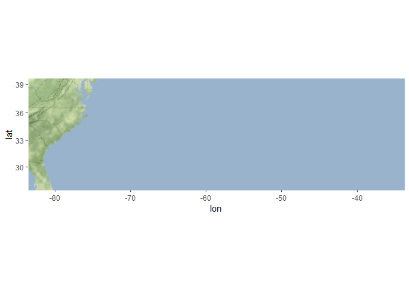

```r
rel_map_base <- get_map(bbox2, maptype = "terrain-background", source = "stamen")
ggmap(rel_map_base)
```

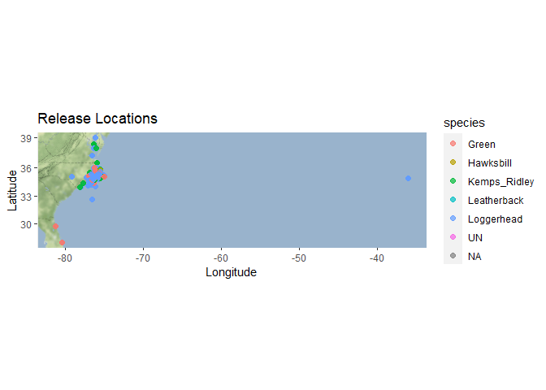

```r
ggmap(rel_map_base) +
  geom_point(data = turtles3, aes(rel_longitude,rel_latitude,color=species), size = 2, alpha = 0.7) +
           labs(x = "Longitude", y = "Latitude", title = "Release Locations")
```

#we can then make additional maps with color or shape of the dots for different variables. We also should pick a unifying color scheme/text/chart and map theme for all of our images (Ideally a color that stands out against the terrain background if we want to stick with terrain for our maps)

#The following are some ideas for graphs that I thought would be good to include, but we can each come up and explore some of our own to compile into the final product

```r
turtles3%>%
  group_by(year)%>%
  summarise(n())
```

```
## # A tibble: 28 x 2
##     year `n()`
##  * <int> <int>
##  1  1988   154
##  2  1989    82
##  3  1990    18
##  4  1991    17
##  5  1992    50
##  6  1993    22
##  7  1994   193
##  8  1995   464
##  9  1996   500
## 10  1997   463
## # ... with 18 more rows
```

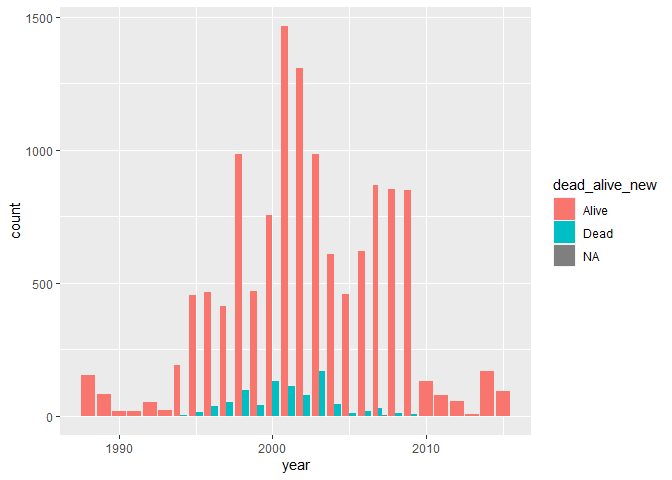

```r
turtles3%>%
  group_by(year)%>%
  ggplot(aes(x=year,fill=dead_alive_new))+
  geom_bar(position = "dodge")
```

```r
turtles3%>%
  group_by(capture_month)%>%
  summarise(n())
```

```
## # A tibble: 12 x 2
##    capture_month `n()`
##  *         <dbl> <int>
##  1             1    41
##  2             2     9
##  3             3     8
##  4             4    15
##  5             5   945
##  6             6  1567
##  7             7  1556
##  8             8  1201
##  9             9   918
## 10            10  2735
## 11            11  4106
## 12            12   334
```

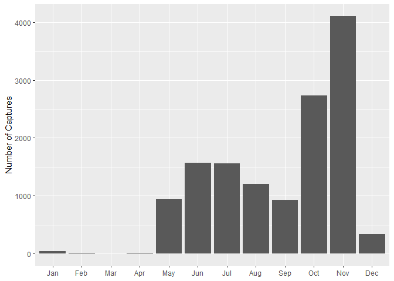

```r
turtles3%>%
  ggplot(aes(month(x=date_capture_new,label=TRUE)))+
  geom_bar(position = "dodge")+
  labs(x = NULL,
         y = "Number of Captures")
```

```r
turtles3%>%
  group_by(capture_day)%>%
  summarise(n())
```

```
## # A tibble: 31 x 2
##    capture_day `n()`
##  *       <int> <int>
##  1           1   432
##  2           2   415
##  3           3   222
##  4           4   383
##  5           5   445
##  6           6   469
##  7           7   487
##  8           8   374
##  9           9   458
## 10          10   586
## # ... with 21 more rows
```

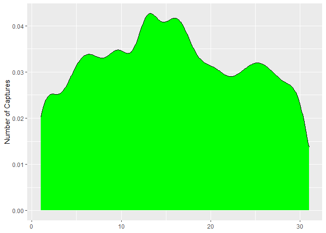

```r
turtles3%>%
  ggplot(aes(day(x=date_capture_new)))+
  geom_density(fill="green")+
  labs(x = NULL,
         y = "Number of Captures")
```

```r
turtles3%>%
  group_by(capture_week_day)%>%
  summarise(n())
```

```
## # A tibble: 7 x 2
##   capture_week_day `n()`
## *            <dbl> <int>
## 1                1   352
## 2                2  3530
## 3                3  2315
## 4                4  1574
## 5                5  1590
## 6                6  3613
## 7                7   461
```

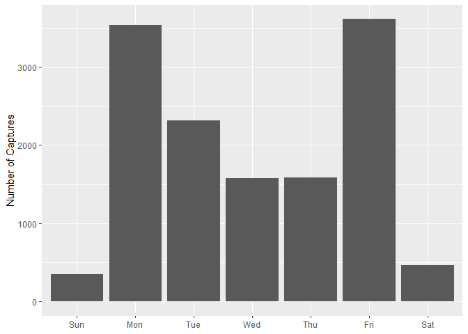

```r
turtles3%>%
  ggplot(aes(wday(x=date_capture_new,label=TRUE)))+
  geom_bar()+
  labs(x = NULL,
         y = "Number of Captures")
```

#Monday and Friday are popular trapping days apparently

```
## geom_path: Each group consists of only one observation. Do you need to adjust
## the group aesthetic?
```

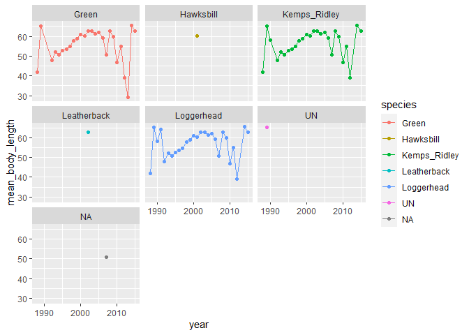

```r
turtles3%>%
  group_by(year)%>%
  mutate(mean_body_length=mean(scl_tip,na.rm=T))%>%
  ggplot(aes(x=year,y=mean_body_length,group=1,color=species))+
  geom_line()+
  geom_point()+
  facet_wrap(~species)
```

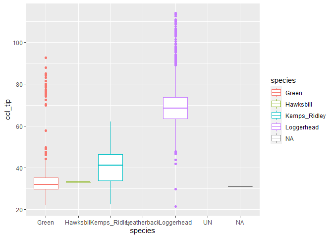

```r
turtles3%>%
  ggplot(aes(x=species,y=ccl_tip,color=species))+
  geom_boxplot()
```

#we of course can fix the axis and replicate this kind of graph for other measurements (SCL_noth/SCl_tip, CCl_notch, etc)

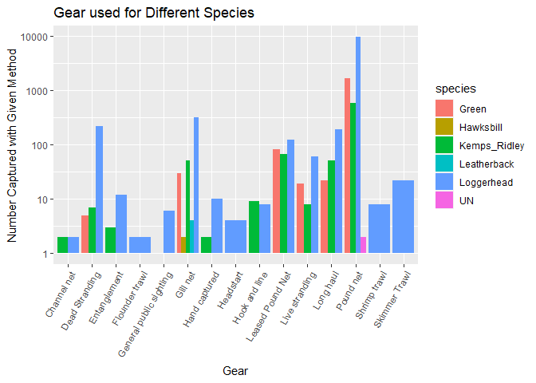

```r
turtles3%>%
  filter(gear!=""&species!="")%>%
  ggplot(aes(x=gear,fill=species))+
  geom_bar(position = "dodge")+
  labs(title = "Gear used for Different Species",x="Gear",y="Number Captured with Given Method")+
  theme(axis.text.x = element_text(angle = 60,hjust = 1))+
  scale_y_log10()
```

```r
names(turtles3)
```

```
##  [1] "year"                     "turtle_id"
##  [3] "research_type"            "date_capture"
##  [5] "species"                  "master_tag"
##  [7] "dead_alive"               "record_type"
##  [9] "inconel_tag"              "body_area"
## [11] "pit_tag"                  "body_area_pit"
## [13] "date_release"             "gear"
## [15] "scl_notch"                "scl_tip"
## [17] "scw"                      "ccl_notch"
## [19] "ccl_tip"                  "ccw"
## [21] "circumference"            "girth"
## [23] "depth_mid"                "tail"
## [25] "weight"                   "cap_region"
## [27] "rel_region"               "cap_latitude"
## [29] "cap_longitude"            "rel_latitude"
```

[output cut: 24 more lines]

#This App is for some categorical variables across the years for different spcecies

```r
library(shinydashboard)
```

```r
turtles3$year<-as.character(turtles3$year)
ui <- dashboardPage(skin="green",
  dashboardHeader(title = "Turtle Captures"),
  dashboardSidebar(disable = F),
  dashboardBody(selectInput("species", "Select Species:",
                  choices=unique(turtles3$species)),
  fluidRow(
  box(title = "Plot Options", width = 4,
  selectInput("x", "Catch Details", choices = c("research_type","dead_alive_new", "body_area_pit","body_area","record_type","cap_region","rel_region"),
              selected = "record_type"),
      hr(),
      helpText("Source: (https://www.fisheries.noaa.gov/inport/item/35875). Capture efforts were conducted to evaluate the growth rates, sex ratios, size distribution, species composition, genetic composition, relative survival rates and foraging ecology of sea turtle populations in NC.")
  ),
  box(title = "Turtle Information", width = 8,
  plotOutput("plot", width = "800px", height = "500px")
  )
  )
  )
  )
server <- function(input, output, session) {

  output$plot <- renderPlot({
  turtles3 %>%
      filter(species == input$species) %>%
  ggplot(aes_string(x ="year",fill = input$x)) +
  geom_bar(position = "dodge")+
       scale_fill_brewer(palette = "Set1")+
  theme_light(base_size = 18)+
     theme(axis.text.x = element_text(angle = 60, hjust = 1))+
      labs(title = "Turtle Catch Characterisitics",x=NULL,y="Number of Turtles")
  })

  session$onSessionEnded(stopApp)
  }

shinyApp(ui, server)
```

Shiny applications not supported in static R Markdown documents

```r
turtles3%>%
  tabyl(haplotype)
```

```
##  haplotype     n      percent valid_percent
##          ?     8 5.954596e-04  0.0040485830
##          A   355 2.642352e-02  0.1796558704
##         A1     4 2.977298e-04  0.0020242915
##         A2     2 1.488649e-04  0.0010121457
##          B   205 1.525865e-02  0.1037449393
##          C    20 1.488649e-03  0.0101214575
##       C,A1     1 7.443245e-05  0.0005060729
##      CcA02     2 1.488649e-04  0.0010121457
##       Cca1     4 2.977298e-04  0.0020242915
##       CcA1   630 4.689245e-02  0.3188259109
##      CcA10    12 8.931894e-04  0.0060728745
##      CcA13     8 5.954596e-04  0.0040485830
##      CcA14    28 2.084109e-03  0.0141700405
##      CcA19     6 4.465947e-04  0.0030364372
##       CcA2   388 2.887979e-02  0.1963562753
##      CcA20     4 2.977298e-04  0.0020242915
##       CcA3    52 3.870488e-03  0.0263157895
##       CcA5     4 2.977298e-04  0.0020242915
##       CcA7     6 4.465947e-04  0.0030364372
##       CcA9     1 7.443245e-05  0.0005060729
##       CmA1    39 2.902866e-03  0.0197368421
##      CmA13     2 1.488649e-04  0.0010121457
##      CmA16     1 7.443245e-05  0.0005060729
##      CmA18     1 7.443245e-05  0.0005060729
##       CmA2     1 7.443245e-05  0.0005060729
##      CmA22     4 2.977298e-04  0.0020242915
##      CmA26     3 2.232974e-04  0.0015182186
##      CmA27     5 3.721623e-04  0.0025303644
##      CmA28     2 1.488649e-04  0.0010121457
##       CmA3    45 3.349460e-03  0.0227732794
##      CmA48     4 2.977298e-04  0.0020242915
##       CmA5     6 4.465947e-04  0.0030364372
##      CmA53     1 7.443245e-05  0.0005060729
##       CmA7     1 7.443245e-05  0.0005060729
##       CmA8    11 8.187570e-04  0.0055668016
##        CMI    20 1.488649e-03  0.0101214575
##      CMIII    18 1.339784e-03  0.0091093117
##        CMV     6 4.465947e-04  0.0030364372
##     CMVIII     4 2.977298e-04  0.0020242915
##    CMXVIII     6 4.465947e-04  0.0030364372
##          D     2 1.488649e-04  0.0010121457
##          E     6 4.465947e-04  0.0030364372
##          G    10 7.443245e-04  0.0050607287
##          H     2 1.488649e-04  0.0010121457
##          I     2 1.488649e-04  0.0010121457
##          J     8 5.954596e-04  0.0040485830
##          M     2 1.488649e-04  0.0010121457
##          N    14 1.042054e-03  0.0070850202
##       REDO    10 7.443245e-04  0.0050607287
##       <NA> 11459 8.529215e-01            NA
```

#This next app shows which tests were perfomed across the years.

```r
turtles3$year<-as.character(turtles3$year)
ui <- dashboardPage(skin="green",
  dashboardHeader(title = "Turtle Capture Tests"),
  dashboardSidebar(disable = F),
  dashboardBody(selectInput("species", "Select Species:",
                  choices=unique(turtles3$species)),
  fluidRow(
  box(title = "Plot Options", width = 4,
  selectInput("x", "Type of Test", choices = c("oxtetracyclene","health_blood","satellite_tag","holding_facility","sex_laparoscopy",     "sex_necropsy","sex_testosterone_level_1","sex_testosterone_level_2","hematology","oc_ob","fh","metals","sia_skin","sia_bone",     "sia_blood","sia_barnacles","sia_scutes","sia_analyzed","photos","scute","cloacal","lesion","fat","fecal","pathogens",     "entangled","imaging","organ_biopsy"),
              selected = "entangled"),
      hr(),
      helpText("Source: (https://www.fisheries.noaa.gov/inport/item/35875). Capture efforts were conducted to evaluate the growth rates, sex ratios, size distribution, species composition, genetic composition, relative survival rates and foraging ecology of sea turtle populations in NC.")
  ),
  box(title = "Test Performed T/F", width = 8,
  plotOutput("plot", width = "800px", height = "500px")
  )
  )
  )
  )
server <- function(input, output, session) {

  output$plot <- renderPlot({
  turtles3 %>%
      filter(species == input$species) %>%
  ggplot(aes_string(x ="year",fill = input$x)) +
  geom_bar(position = "dodge")+
       scale_fill_brewer(palette = "Set1")+
  theme_light(base_size = 18)+
     theme(axis.text.x = element_text(angle = 60, hjust = 1))+
      labs(title = "Tests Performed On Turtles",x=NULL,y="Number of Turtles Tested for Selected Test")
  })

  session$onSessionEnded(stopApp)
  }

shinyApp(ui, server)
```

Shiny applications not supported in static R Markdown documents

Quantitative Data Apps (rought first idea, will adjust aes on Thursday)

```r
ui <- dashboardPage(
  dashboardHeader(title = "Turtle Measurements"),
  dashboardSidebar(disable = T),
  dashboardBody(
  fluidRow(
  box(
  selectInput("x", "Select X Variable", choices = c("scl_notch ", "scl_tip", "scw", "ccl_notch", "ccl_tip", "ccw", "circumference", "tail", "girth", "depth_mid", "weight"), selected = "scl_notch"),
  selectInput("y", "Select Y Variable", choices = c("scl_notch ", "scl_tip", "scw", "ccl_notch", "ccl_tip", "ccw", "circumference", "tail", "girth", "depth_mid", "weight"), selected = "scl_notch"),
  ), # close the first box
  box(
  plotOutput("plot", width = "500px", height = "500px")
  )
  )
  )
)

server <- function(input, output, session) {
  output$plot <- renderPlot({
  ggplot(turtles3, aes_string(x = input$x, y = input$y)) + geom_point(alpha=0.8) + theme_light(base_size = 18)
  })
  session$onSessionEnded(stopApp)
  }

shinyApp(ui, server)
```

Shiny applications not supported in static R Markdown documents

```r
ui <- dashboardPage(
  dashboardHeader(title = "Turtle Measurements"),
  dashboardSidebar(disable = T),
  dashboardBody(
  fluidRow(
  box(
  selectInput("x", "Select X Variable", choices = c("cap_latitude", "cap_longitude"), selected = "scl_notch"),
  selectInput("y", "Select Y Variable", choices = c("scl_notch ", "scl_tip", "scw", "ccl_notch", "ccl_tip", "ccw", "circumference", "tail", "girth", "depth_mid", "weight"), selected = "scl_notch"),
  ), # close the first box
  box(
  plotOutput("plot", width = "500px", height = "500px")
  )
  )
  )
)

server <- function(input, output, session) {
  output$plot <- renderPlot({
  ggplot(turtles3, aes_string(x = input$x, y = input$y)) + geom_point(alpha=0.8) + theme_light(base_size = 18)
  })
  session$onSessionEnded(stopApp)
  }

shinyApp(ui, server)
```

Shiny applications not supported in static R Markdown documents

#My second app was an interesting idea, but it doesn’t come out that pretty. Might just make some new maps where I scale point size by turtle weight, size, or depth.

Additional Graph Ideas:

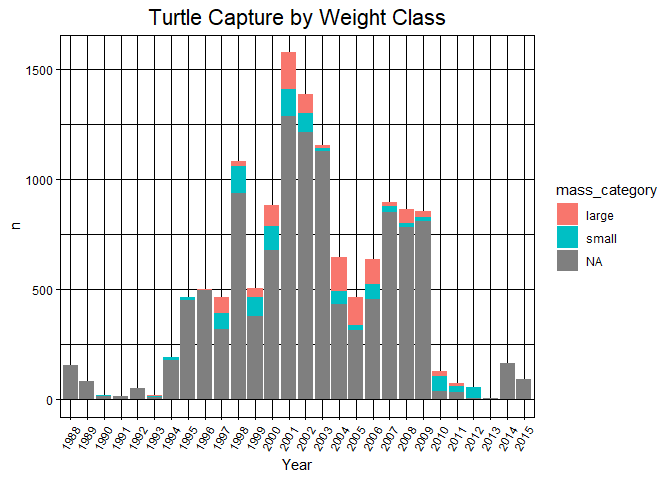

```r
turtles3 %>%
    mutate(mass_category = case_when(weight <= 30 ~ "small", weight >= 30 ~ "large")) %>%
  group_by(year) %>%
  ggplot(aes(x = year, fill = mass_category))+
  geom_bar()+
  labs(title = "Turtle Capture by Weight Class",
       x = "Year",
       y= "n")+
    theme_linedraw()+
  theme(axis.text.x = element_text(angle = 60, hjust = 1), plot.title = element_text(size = rel(1.5), hjust = 0.5))
```

#test data